# 波动率因子研究

陶阿明

2016/11/23

## 一、因子综述

### (一)指数概览

**股票波动率即股票区间收益率的标准差**。在研究波动率因子之前，先介绍几个波动率相关的指数。

中证指数公司于2012年1月9日，发布了沪深300波动率加权指数(000803.CSI，以下简称300波动)、中证500波动率加权指数(000804.CSI，以下简称500波动)，指数成分股均为100只。波动率加权指数是以标的指数为样本空间，选取历史波动率最小的100只股票作为样本股，且以历史波动率的倒数为权重，波动率越小权重越大，波动率越大权重越小。具体的指数编制方案可以参见中证指数公司官网。

300波动和500波动及标的指数的历史走势如下图。

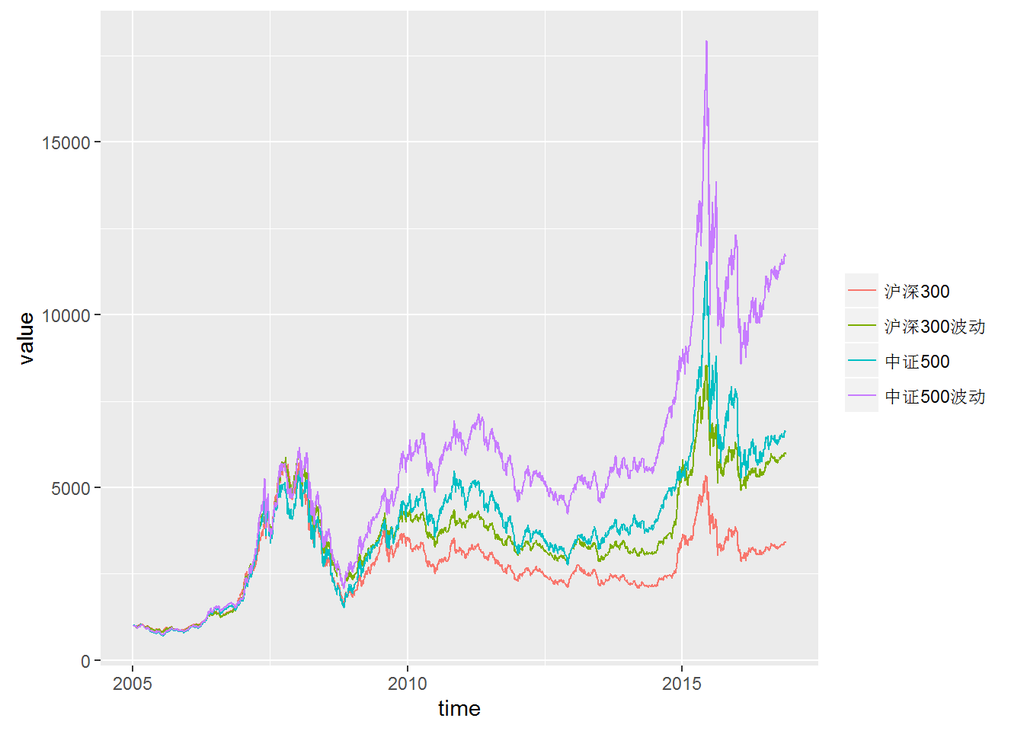

300波动和500波动及标的指数的历史收益统计如下表。

500波动是一个10年10倍的指数。300波动和500波动的累积收益均为标的指数的两倍左右，年化收益率平均超过标的指数5-6个百分点，夏普值和最大回撤均优于标的指数，且在过去12年间大部分年份跑赢标的指数。

波动率指数近似一个等权指数，成分股的权重差别很小。

|  | 沪深300 | 沪深300波动 | 中证500 | 中证500波动 |
| --- | --- | --- | --- | --- |
| 2005-01-04 ~ 2005-12-30 | -7.7% | -8.8% | -12.8% | -10.1% |
| 2006-01-04 ~ 2006-12-29 | 121% | 105.7% | 100.7% | 100.6% |
| 2007-01-04 ~ 2007-12-28 | 161.5% | 207% | 186.6% | 216% |
| 2008-01-02 ~ 2008-12-31 | -65.9% | -59% | -60.8% | -54.5% |
| 2009-01-05 ~ 2009-12-31 | 96.7% | 84% | 131.3% | 130.4% |
| 2010-01-04 ~ 2010-12-31 | -12.5% | -8.4% | 10.1% | 7.1% |
| 2011-01-04 ~ 2011-12-30 | -25% | -20.4% | -33.8% | -24% |
| 2012-01-04 ~ 2012-12-31 | 7.6% | 4.1% | 0.3% | 2.3% |
| 2013-01-04 ~ 2013-12-31 | -7.6% | 1.5% | 16.9% | 15.5% |
| 2014-01-02 ~ 2014-12-31 | 51.7% | 69.6% | 39% | 54.5% |
| 2015-01-05 ~ 2015-12-31 | 5.6% | 9.5% | 43.1% | 37.3% |
| 2016-01-04 ~ 2016-11-21 | -7.8% | -1.9% | -13.2% | -2.3% |
| Cumulative Return | 244.1% | 509.8% | 569.9% | 1089.5% |
| Annualized Return | 11% | 16.4% | 17.3% | 23.2% |
| Annualized StdDev | 28.8% | 27.2% | 32.8% | 31.5% |
| Annualized Sharpe(Rf=0%) | 38% | 60.3% | 52.8% | 73.5% |
| Worst Drawdown | 72.3% | 65.8% | 72.4% | 66.7% |

以上波动率指数的构建方法都是传统的打分排序，此外中证指数公司跟风险模型提供商Axioma合作发布了两个波动率优化指数，优化高波(H30129.CSI)，优化低波(H30130.CSI)，均是在沪深300成分股内进行选股。

优化指数是基于Axioma的风险模型和优化算法，选取不定数量的样本，实现特定因子的最大暴露，其他因子接近中性暴露。目前优化指数已停止更新，这里仅作展示，不深入研究。

优化指数走势如下图。

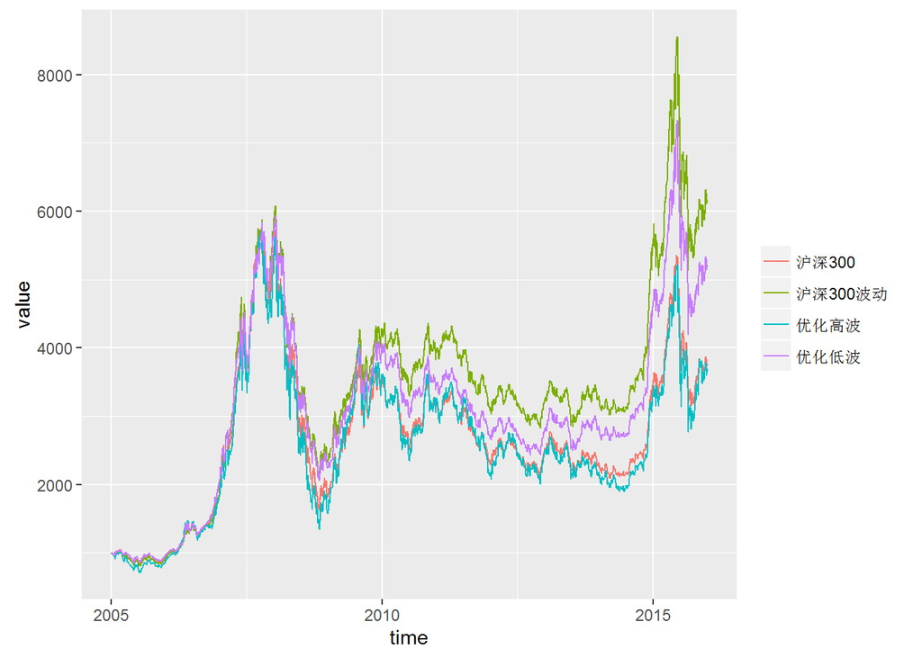

300波动和优化指数的历史收益统计如下表。从业绩表现来看，传统的打分排序构建的组合不输于优化的组合。

|  | 沪深300 | 沪深300波动 | 优化高波 | 优化低波 |
| --- | --- | --- | --- | --- |
| 2005-01-04 ~ 2005-12-30 | -7.7% | -8.8% | -12.9% | -4.4% |
| 2006-01-04 ~ 2006-12-29 | 121% | 105.7% | 112.4% | 116.7% |
| 2007-01-04 ~ 2007-12-28 | 161.5% | 207% | 180.6% | 173.3% |
| 2008-01-02 ~ 2008-12-31 | -65.9% | -59% | -69.1% | -59.8% |
| 2009-01-05 ~ 2009-12-31 | 96.7% | 84% | 129.6% | 81.3% |
| 2010-01-04 ~ 2010-12-31 | -12.5% | -8.4% | -12.5% | -15.5% |
| 2011-01-04 ~ 2011-12-30 | -25% | -20.4% | -31.1% | -21% |
| 2012-01-04 ~ 2012-12-31 | 7.6% | 4.1% | 15% | 3.9% |
| 2013-01-04 ~ 2013-12-31 | -7.6% | 1.5% | -12.7% | 1.3% |
| 2014-01-02 ~ 2014-12-31 | 51.7% | 69.6% | 53.7% | 64% |
| 2015-01-05 ~ 2015-12-31 | 5.6% | 9.5% | 8.5% | 10.6% |
| Cumulative Return | 273.1% | 521.7% | 272% | 426.3% |
| Annualized Return | 12.7% | 18.1% | 12.7% | 16.3% |
| Annualized StdDev | 29.2% | 27.7% | 34.9% | 26.6% |
| Annualized Sharpe(Rf=0%) | 43.5% | 65.3% | 36.3% | 61.4% |
| Worst Drawdown | 72.3% | 65.8% | 76.5% | 65.4% |

### (二)因子效果展示

从上面的研究可以看出，波动率是一个负向因子。**波动率因子暂定为过去250个交易日日收益率的标准差**。

中证全指样本空间波动率因子IC序列如下图所示。因子的IC均值0.011，IC标准差0.16，IC胜率56.7%，就IC来看，波动率因子表现一般。

```
## Function getTSR: getting the periodrtn ....
## [memory data loading]
##   Loading the market trading days: '.tradingdays' ...
##   Loading the stocks' untrading days: '.QT_UnTradingDay' ...
```

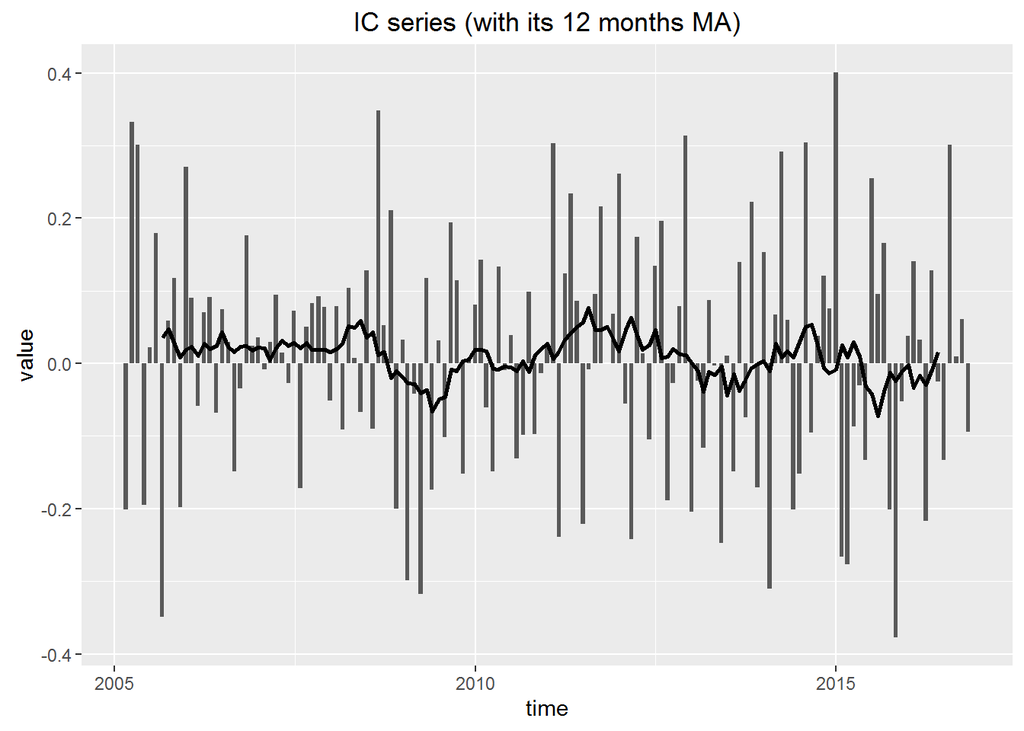

全市场因子分组的年化收益率如下图所示。波动率因子并没有明显的单调性。

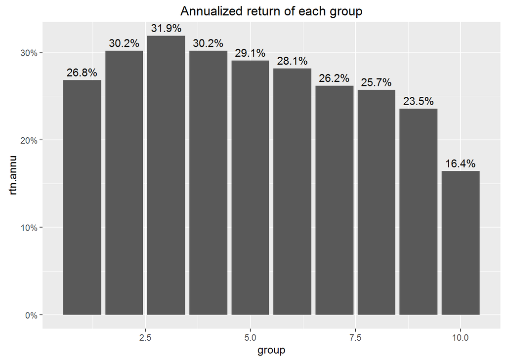

因子多空收益如下图所示。波动率因子多空收益表现不稳定。

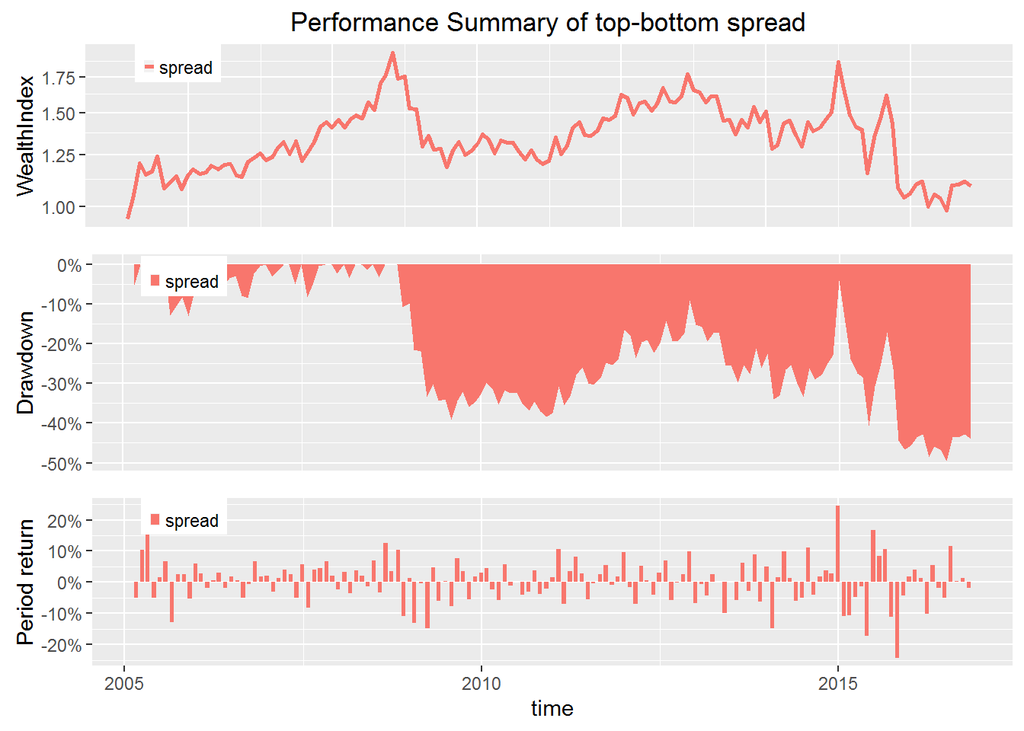

### (三)因子参数调整

截至目前，波动率因子并不是一个很好的因子。不过不同因子适用的调仓频率可能不太一样。上面都是假设每个月调仓一次。下图展示的是季度调仓的因子IC序列。

季度调仓的因子IC表现明显提升。IC均值0.037，IC标准差0.13，IC胜率60%，各项指标大幅优于月度调仓。

```
## Function getTSR: getting the periodrtn ....
```

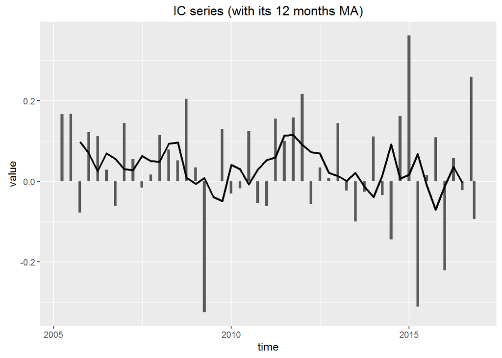

下图展示的是半年度调仓的因子IC序列。

半年度调仓的因子IC表现再度提升。因子的IC均值0.054，IC标准差0.14，IC胜率71%。不过半年度调仓IC样本数量较少，可能导致结论偏差较大。

```
## Function getTSR: getting the periodrtn ....
```

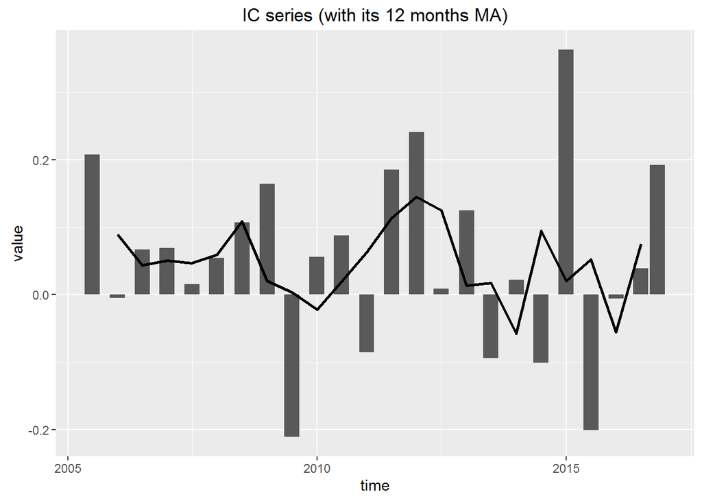

除了调整调仓频率，收益区间也可以调整。目前默认是250个交易日。下图展示的是20个交易日的波动率因子IC序列。

IC均值0.015，IC标准差0.14，IC胜率58.2%，就IC来看，较250日有一定的改善。

```
## Function getTSR: getting the periodrtn ....
```

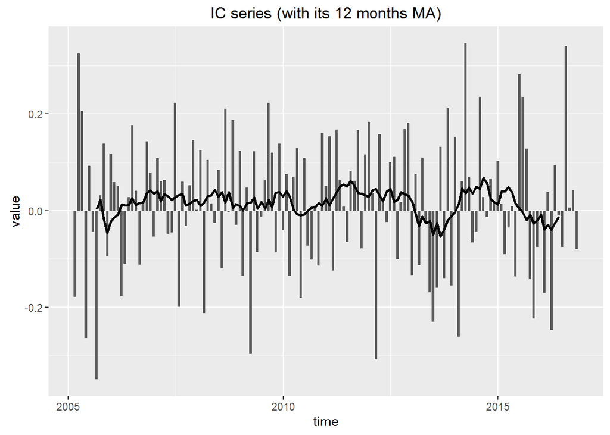

下图展示的是60个交易日的波动率因子IC序列。IC均值0.015，IC标准差0.16，IC胜率54.6%，整体差于20个交易日的波动率因子。

```
## Function getTSR: getting the periodrtn ....
```

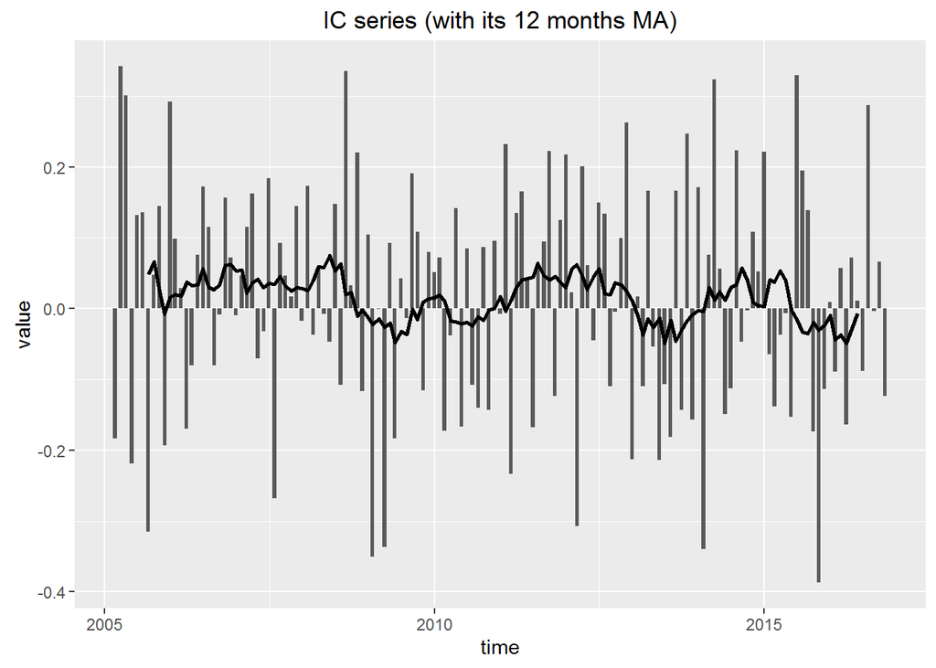

我们无意去遍历所有可能参数组合，这样有过度挖掘的嫌疑。结合前面的参数分析，我们不妨认为季度调仓20个交易日波动率组合是一个比较不错的参数组合。

该参数组合下因子IC如下图所示。因子的IC均值0.043，IC标准差0.11，IC胜率65%。接下去的研究都是基于该参数组合。

```
## Function getTSR: getting the periodrtn ....
```

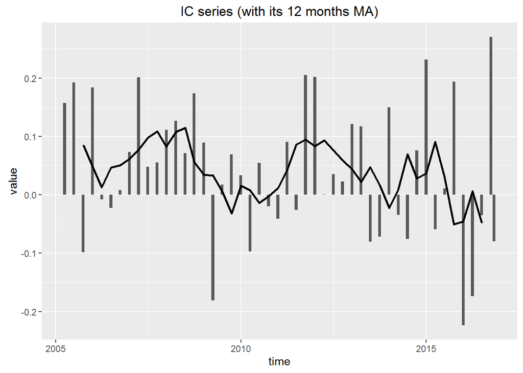

新参数组合下全市场波动率因子分组的年化收益率如下图所示。波动率因子分组收益率的单调性有所增强。

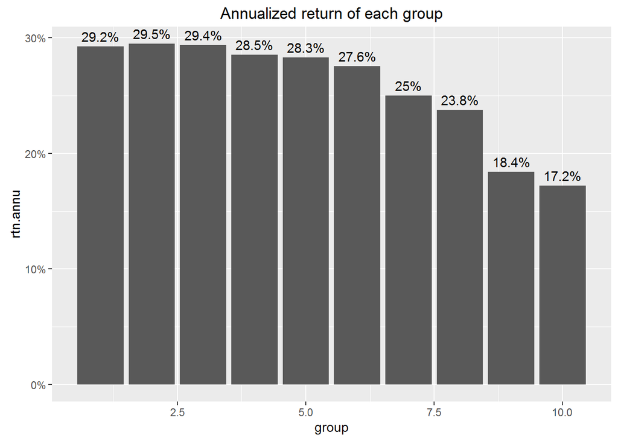

新参数组合下因子多空收益如下图所示。因子多空收益依然不稳定。

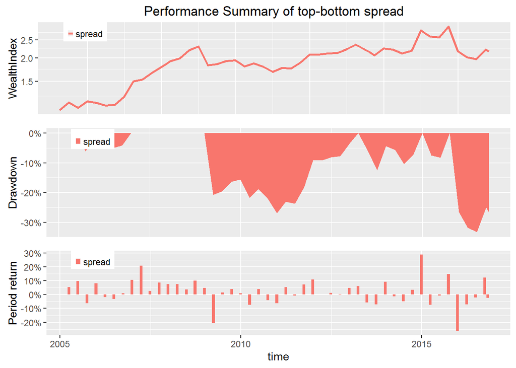

### (四)纯因子组合

纯因子组合是剔除了市值、行业、反转、净利润增速等风险特征的纯因子组合，更能有效的反映因子的alpha性。

纯因子组合收益率如下图所示。波动率因子在剥离了行业、市值、反转、PB、净利润增速之后的任然能够贡献alpha，虽然表现不及其他几个传统的因子。

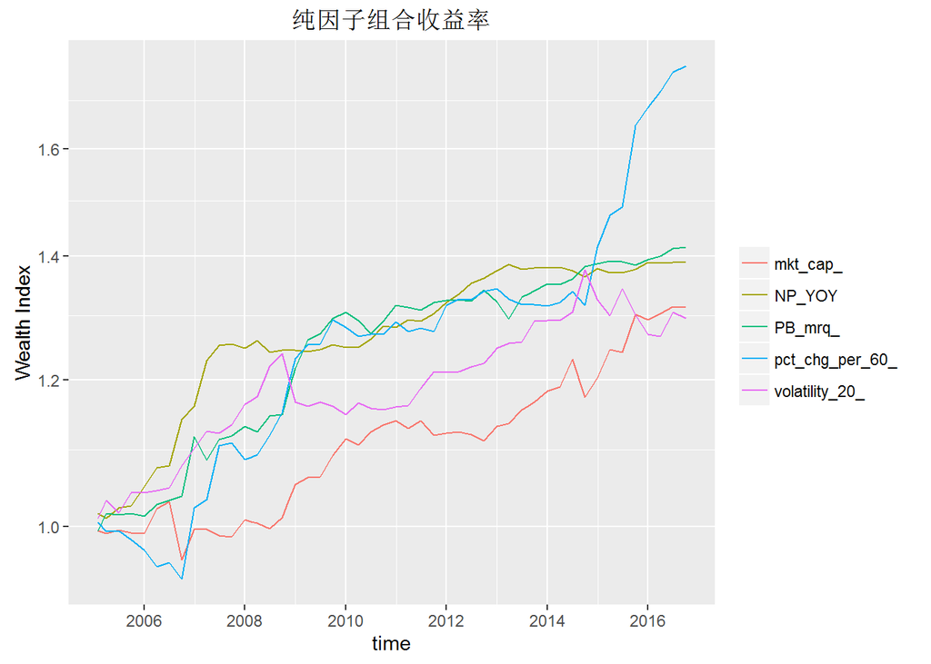

纯因子组合收益率统计如下表：

|  | mkt_cap_ | NP_YOY | PB_mrq_ | pct_chg_per_60_ | volatility_20_ |
| --- | --- | --- | --- | --- | --- |
| 2005-01-31 ~ 2005-12-30 | -0.9% | 5.1% | 1.3% | -2.8% | 4.3% |
| 2006-03-31 ~ 2006-12-29 | 0.5% | 10.5% | 10.4% | 5.3% | 5.6% |
| 2007-03-30 ~ 2007-12-28 | 1.2% | 7.5% | 1.3% | 6.2% | 5.7% |
| 2008-03-31 ~ 2008-12-31 | 4.5% | -0.3% | 7.5% | 13.4% | 0.2% |
| 2009-03-31 ~ 2009-12-31 | 5.9% | 0.3% | 7.3% | 4% | -1.5% |
| 2010-03-31 ~ 2010-12-31 | 2.3% | 2.6% | 0.8% | 0.7% | 0.9% |
| 2011-03-31 ~ 2011-12-30 | -1.6% | 3.1% | 0.6% | 2% | 4.4% |
| 2012-03-30 ~ 2012-12-31 | 0.9% | 4.1% | -0.2% | 2.1% | 3% |
| 2013-03-29 ~ 2013-12-31 | 4.5% | 0.3% | 2.3% | -2.1% | 3.6% |
| 2014-03-31 ~ 2014-12-31 | 1.6% | 0% | 2.5% | 7.6% | 2.6% |
| 2015-03-31 ~ 2015-12-31 | 7.5% | 0.7% | 0.5% | 19% | -4.3% |
| 2016-03-31 ~ 2016-09-30 | 1.6% | 0% | 1.6% | 5.3% | 2% |
| Cumulative Return | 31.4% | 38.9% | 41.6% | 77.5% | 29.6% |
| Annualized Return | 2.3% | 2.8% | 3% | 4.9% | 2.2% |
| Annualized StdDev | 4.1% | 2.8% | 3.6% | 5.7% | 4% |
| Annualized Sharpe(Rf=0%) | 56.8% | 101.6% | 82.5% | 86.1% | 54.7% |
| Worst Drawdown | 7% | 1.5% | 3.5% | 6.9% | 8% |

## 二、核心指数回测

上面的测试都是全市场测试，下面将在沪深300和中证500里面分别测试因子的效果。

### (一)沪深300

沪深300指数成分股内多空组合表现如下图所示：

```
## Function getTSR: getting the periodrtn ....
```

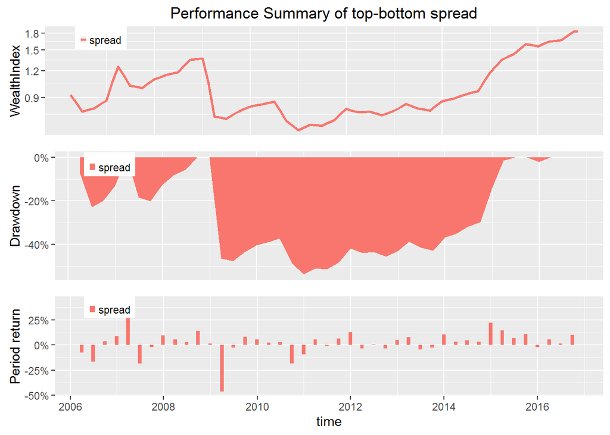

### (二)中证500

中证500指数成分股内多空组合表现如下图所示：

```
## Function getTSR: getting the periodrtn ....
```

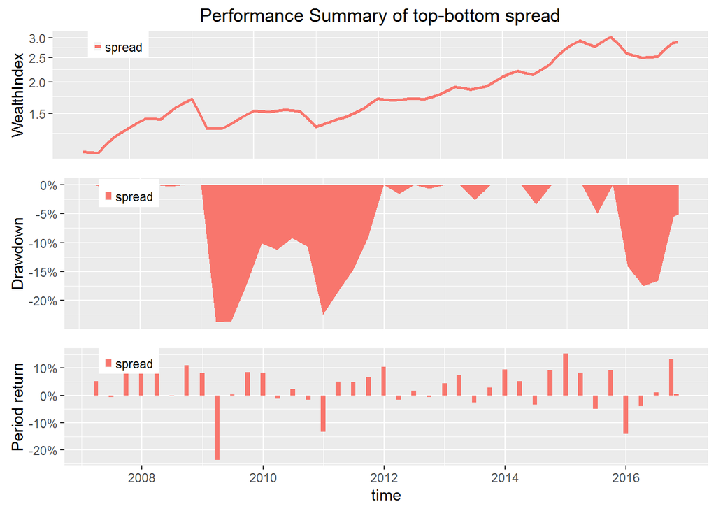

### (三)指数统计

两个指数中因子的IC统计和因子的多空组合收益率如下表所示。波动率因子在中证500成分股里表现要优于沪深300。

|  | EI000300 | EI000905 |
| --- | --- | --- |
| IC均值 | 0.054 | 0.056 |
| IC标准差 | 0.146 | 0.117 |
| ICIR | 0.372 | 0.480 |
| IC胜率 | 0.682 | 0.725 |
| 多空组合年化收益 | 0.058 | 0.114 |
| 多空组合年化波动率 | 0.258 | 0.160 |
| 多空组合年化夏普 | 0.224 | 0.710 |
| 多空组合最大回撤 | 0.538 | 0.237 |

## 三、大类行业回测

### (一)大周期

大周期覆盖农林牧渔、采掘、化工、钢铁、有色金属。

```
## Function getTSR: getting the periodrtn ....
```

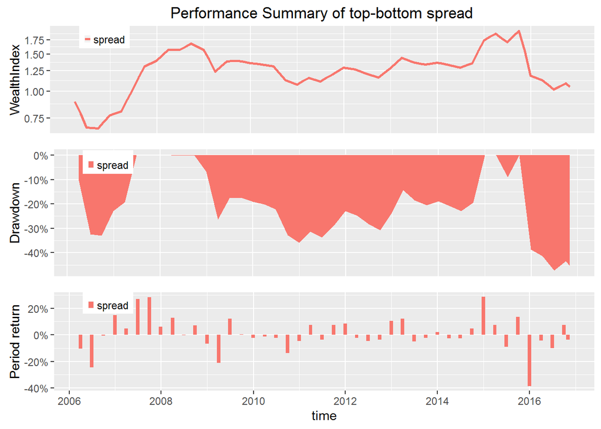

### (二)金融地产

金融地产组覆盖银行、非银、房地产。

```
## Function getTSR: getting the periodrtn ....
```

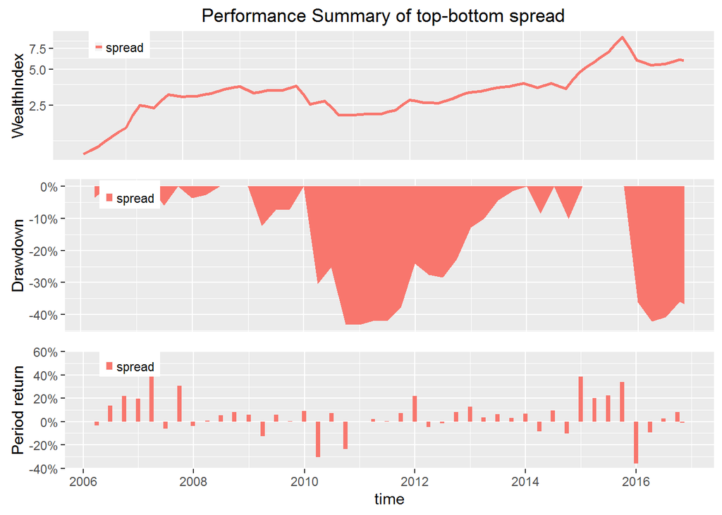

### (三)TMT

TMT覆盖电子、计算机、传媒、通信。

```
## Function getTSR: getting the periodrtn ....
```

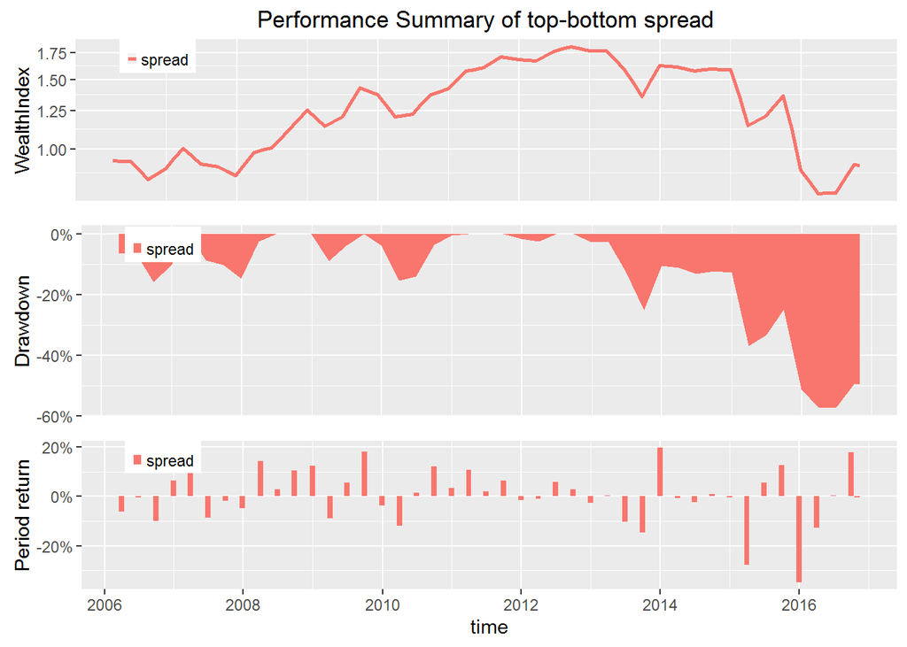

### (四)大消费

大消费覆盖汽车、家用电器、食品饮料、纺织服装、休闲服务、医药生物、商业贸易。

```
## Function getTSR: getting the periodrtn ....
```

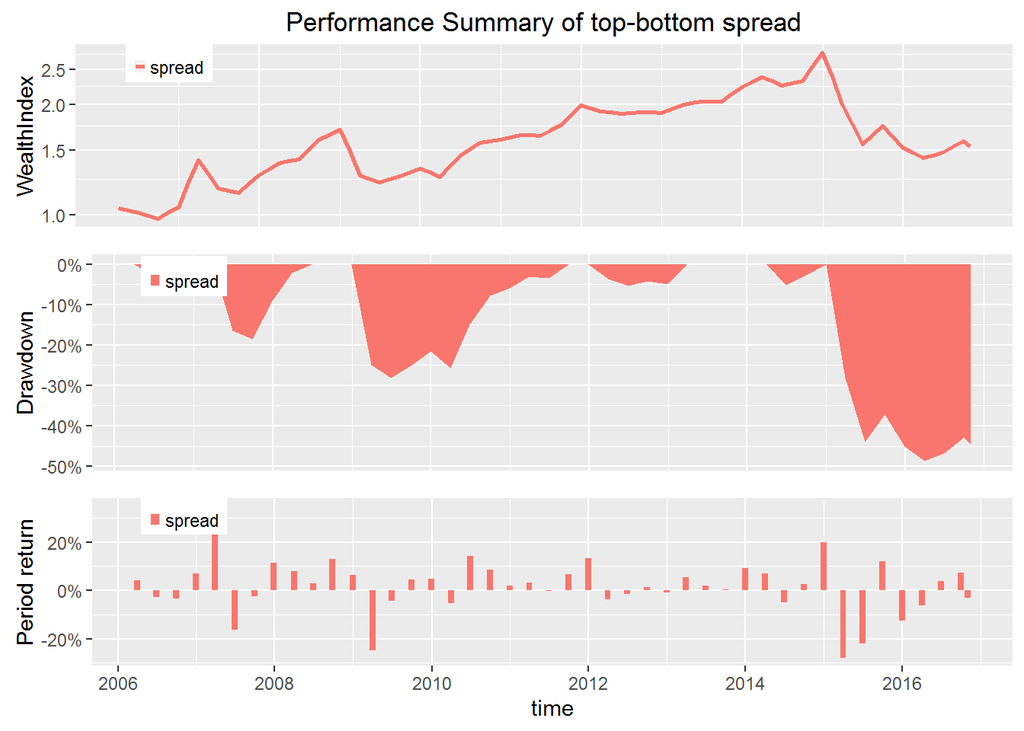

### (五)制造组

制造组覆盖轻工制造、建筑材料、建筑建材、电气设备、机械设备、国防军工。

```
## Function getTSR: getting the periodrtn ....
```

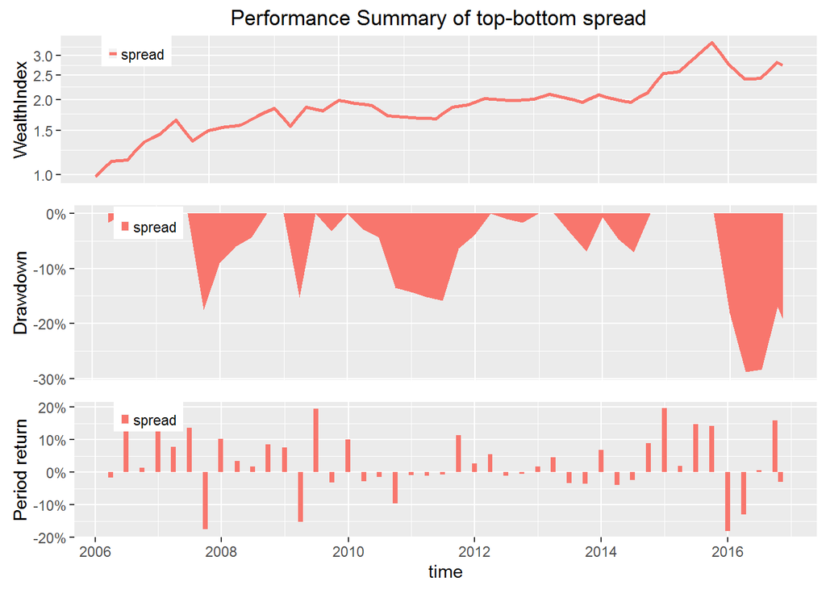

### (六)其他

其他覆盖公共事业、交通运输、综合。

```
## Function getTSR: getting the periodrtn ....
```

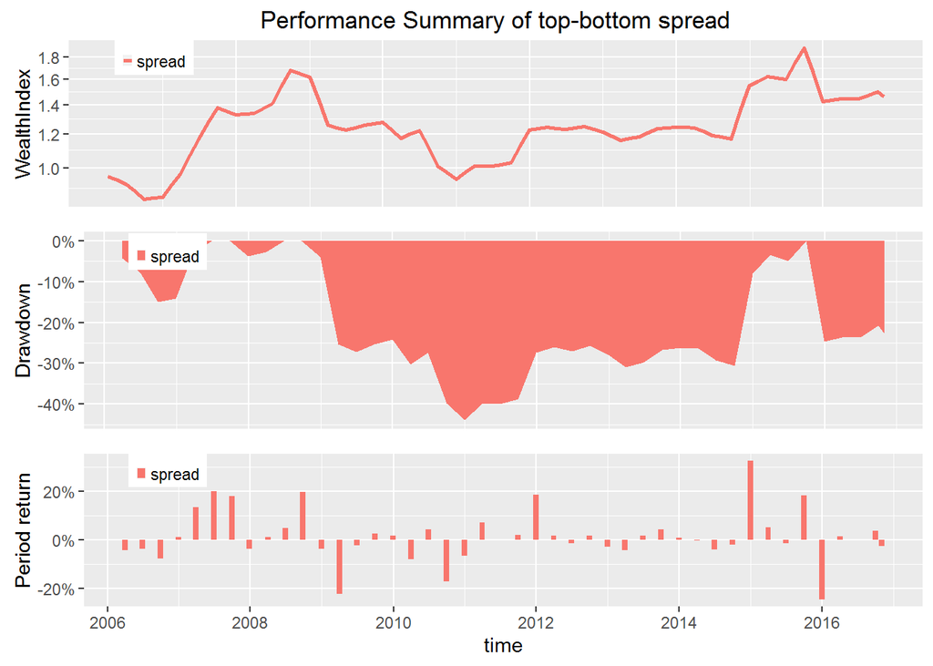

### (七)行业统计

大类行业中因子的IC统计和因子的多空组合收益率如下表所示。波动率因子在金融地产中表现最好，制造业中表现也不错。

|  | 周期 | 金融地产 | TMT | 消费 | 制造 | 其他 |
| --- | --- | --- | --- | --- | --- | --- |
| IC均值 | 0.018 | 0.076 | 0.037 | 0.046 | 0.035 | 0.031 |
| IC标准差 | 0.132 | 0.161 | 0.139 | 0.131 | 0.112 | 0.128 |
| ICIR | 0.136 | 0.472 | 0.262 | 0.351 | 0.309 | 0.243 |
| IC胜率 | 0.477 | 0.750 | 0.591 | 0.659 | 0.636 | 0.659 |
| 多空组合年化收益 | 0.005 | 0.179 | -0.008 | 0.041 | 0.097 | 0.036 |
| 多空组合年化波动率 | 0.256 | 0.337 | 0.222 | 0.226 | 0.189 | 0.214 |
| 多空组合年化夏普 | 0.019 | 0.531 | -0.037 | 0.180 | 0.516 | 0.167 |
| 多空组合最大回撤 | 0.472 | 0.431 | 0.573 | 0.486 | 0.288 | 0.438 |